# Mini-cursos: Introdução ao R - Mapeamento Genético - Sequenciamento de RNA e Expressão Diferencial

Para todas as práticas é necessário fazer o download da pasta "Arquivos_Workshop-master" no menu localizado no canto direito superior desta página.

No menu você também encontrará as apresentações teóricas e outras informações.

## Expressão diferencial {prática}

28 Jul 2015

### Introdução

O primeiro passo é utilizar um arquivo de contagem bruta de leituras para cada gene, em cada uma das réplicas das diferentes condições utilizadas no experimento que deu origem aos dados do sequenciamento de RNA.

A tabela de contagem é o *input* para o pacote, sendo obtida através das leituras de RNA-Seq que se alinharam aos genes a partir de uma referência já anotada. Cada célula representa as contagens para um gene $i$ na amostra $j$. O DESeq2 utiliza um modelo estatístico em que só são necessárias as contagens brutas.

Nota-se a importância de que cada coluna represente as réplicas biológicas. Se houver réplicas técnicas, recomenda-se somá-las em uma única coluna.

### Bioconductor

O [Bioconductor](http://bioconductor.org/about/) é uma fonte aberta baseada em linguagem [R](https://www.r-project.org/), iniciada no ano de 2001, cujo objetivo principal é fornecer ferramentas para análise e compreensão de dados de plataformas de alto rendimento na forma de pacotes para o R.

Para a obtenção dos pacotes, como o [DESeq2](http://bioconductor.org/packages/release/bioc/html/DESeq2.html) os seguintes comandos são utilizados no ambiente R:

```r
source("http://bioconductor.org/biocLite.R")

biocLite() #Coloca-se entre aspas o pacote desejado.
```

### Arquivos para a prática

Os arquivos para as práticas de Introdução ao R, Mapeamento Genético e Expressão Diferencial, realizadas no IX Workshop de Genética e Melhoramento de Plantas, podem ser encontradas [aqui](http://cristianetaniguti.github.io/index.html).

### DESeq2

O conjunto de dados advém de um experimento de RNA-Seq em *Arabidopsis thaliana* para buscar uma resposta de defesa à infecção por uma bactéria ( mutante $\Delta hrcC$ de *Pseudomonas syringae* ). Há réplicas biológicas para cada um dos tratamentos. O RNA foi isolado 7 horas após a inoculação, enriquecido para mRNA e preparado para RNA-Seq.

1. Mude seu diretório para a pasta “Expre”.
2. Carregue o pacote “DESeq2”.
3. Leia a tabela “arabidopsis” e armazene em um vetor.
4. Transforme a tabela arabidopsis em um *data frame*, armazene no mesmo vetor.

```r
library("DESeq2")

counts <- read.table("arabidopsis", header = TRUE)

counts <- as.data.frame(counts)
```

Observe as contagens.

```r
head(counts)

tail(counts)
```

*Perguntas*:

**Quantas amostras possuímos em nosso experimento???**

**Quantos genes há na tabela?**

(Dica: Utilize a *dimensão*)

Para utilizar o pacote DESeq2 deve-se criar metadados, que são arquivos de dados sobre outros dados. Um deles trata-se da informação sobre as amostras, contida nas colunas, dessa forma cria-se um arquivo para especificar o intuito do experimento.

Dessa forma, o software verificará, posteriormente, quais foram os tratamentos utilizados no experimento. Para isso, é necessário criar um vetor que relacione as réplicas da matriz de contagem com as condições.

```r
expDesign <- data.frame(row.names = colnames(counts), condition = c(rep("mock",3), rep("hrcc",3)))

expDesign
```

```
##       condition
## mock1      mock
## mock2      mock
## mock3      mock
## hrcc1      hrcc
## hrcc2      hrcc
## hrcc3      hrcc
```

Dessa forma $expDesign$ é um *data frame* de informação sobre as **amostras**, onde as linhas ligam-se diretamente com as colunas da tabela de contagem.

Com a matriz de contagem e a informação das amostras, constrói-se o $DESeqDataSet$:

```r
dds <- DESeqDataSetFromMatrix(countData = counts, colData = expDesign, design = ~condition)

dds
```

```
## class: DESeqDataSet
## dim: 26222 6
## exptData(0):
## assays(1): counts
## rownames(26222): AT1G01010 AT1G01020 ... AT5G67630 AT5G67640
## rowData metadata column names(0):
## colnames(6): mock1 mock2 ... hrcc2 hrcc3
## colData names(1): condition
```

A análise de expressão diferencial no DESeq2 utiliza:

$K_{ij} \sim NB(\mu_{ij}, \alpha_{i})$

$\mu_{ij} = s_{j}q_{ij}$

As contagens $K_{ij}$ para o gene $i$ na amostra $j$ são modeladas usando uma distribuição binomial negativa com média ajustada $\mu_{ij}$ e um padrão de dispersão gene específico $\alpha_{i}$.

A média ajustada é composta por um fator de tamanho específico de amostra $s_{j}$ e um parâmetro $q_{ij}$ proporcional à concentração verdadeira de fragmentos para a amostra $j$.

Emprega-se a função DESeq:

```r
dds  <- DESeq(dds)
```

#### Compreendendo o Log2 Fold Change

```r
#Considere duas contagens:

condA <- 30

condB <- 300

#O Fold Change representa a razão entre elas.

foldChange <- condB/condA
```

**Qual o valor do Fold Change?**

Ou seja, se a contagem da condição B for maior do que a de A, o *Fold Change* será maior do que um. Se a contagem em A for maior do que em B, o *Fold Change* será inferior a um.

```r
#Já que razão também pode ser:

foldChange <- condA/condB
```

**Qual o valor desse Fold Change?**

No que implicaria utilizar apenas o *Fold Change*?

```r
#Vamos utilizar mais contagens???

condA <- seq(from = 30, to = 300, by= 30)

condB <- seq(from = 300, to = 30, by= -30)


foldChange <- condB/condA


dados <- data.frame(condA, condB, foldChange, condA.maior.condB = condA > condB)
```

**Observe os dados.**

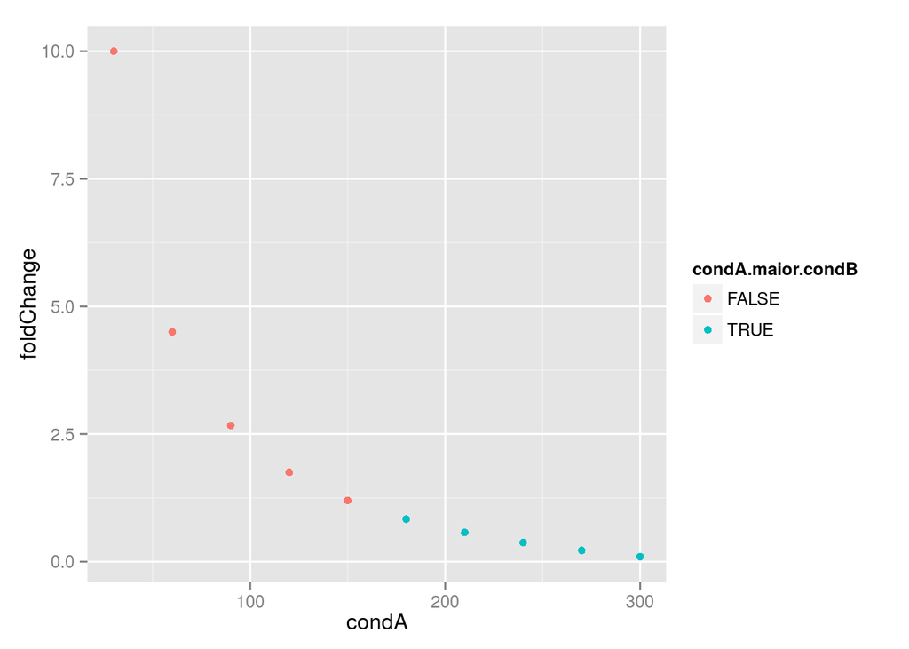

```r
library("ggplot2")

ggplot(dados, aes(condA, foldChange, colour = condA.maior.condB), size = 8) + geom_point()
```

Agora podemos utilizar o log2:

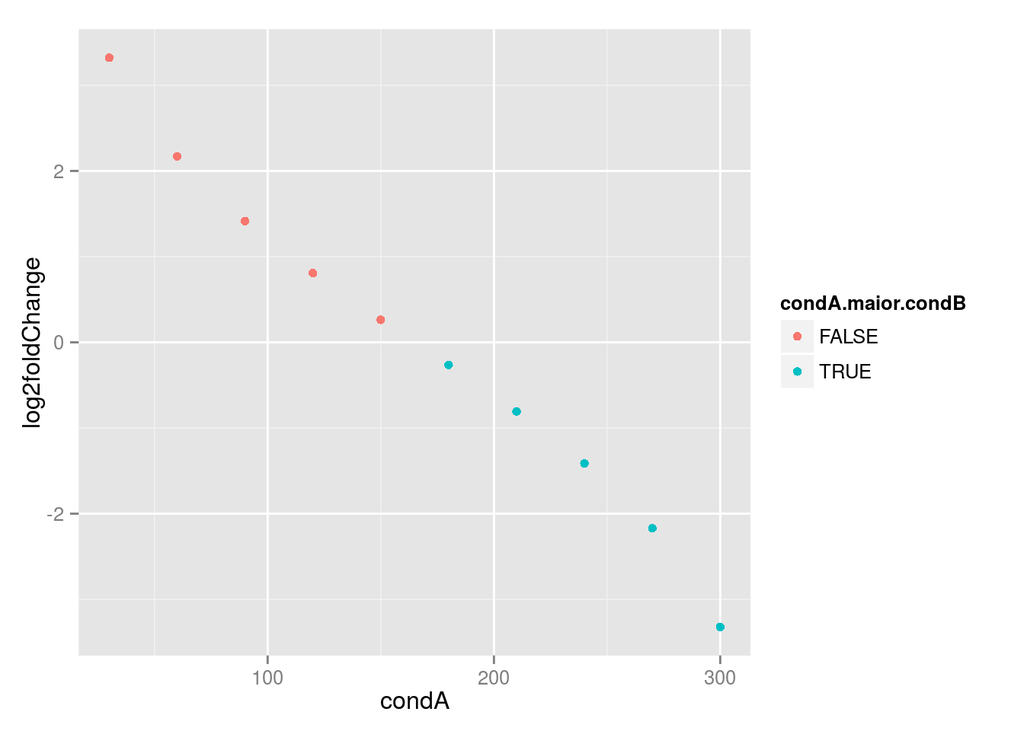

```r
log2foldChange <- log2(foldChange)


dados <- data.frame(condA, condB, foldChange, log2foldChange, condA.maior.condB = condA > condB)

#Observe os dados agora

ggplot(dados, aes(condA, log2foldChange, colour = condA.maior.condB), size = 8) + geom_point()
```

- Simetria
- Fácil Visualização

A função $results$ gera a tabela de resultados, com o $log2FoldChange$, valor-$p$ e valor-$p$ ajustado.

```r
res <- results(dds)
head(res)
```

**Utilize a função $head$ na matriz de contagem.**

**O que você observa?**

Ao verificarmos o $log2FoldChange$, que é a estimativa do tamanho do efeito, notamos que se trata:

$log_2(mock/hrcc)$

*Porque utiliza-se a escala logarítmica?*

Os genes podem ser colocados em ordem a partir daqueles mais diferencialmente expressos:

```r
resOrderd <- res[order(res$padj),]
head(resOrderd)
```

Para se verificar a quantidade de genes *up*-regulated, *down*-regulated, ouliers e genes de baixas contagens.

```r
summary(res)
```

No DESeq2 a função $plotMA$ mostra o $log2$ fold change sobre a média das contagens normalizadas. Se o valor do valor-$p$ ajustado for inferior a 0.1, será colorido de vermelho.

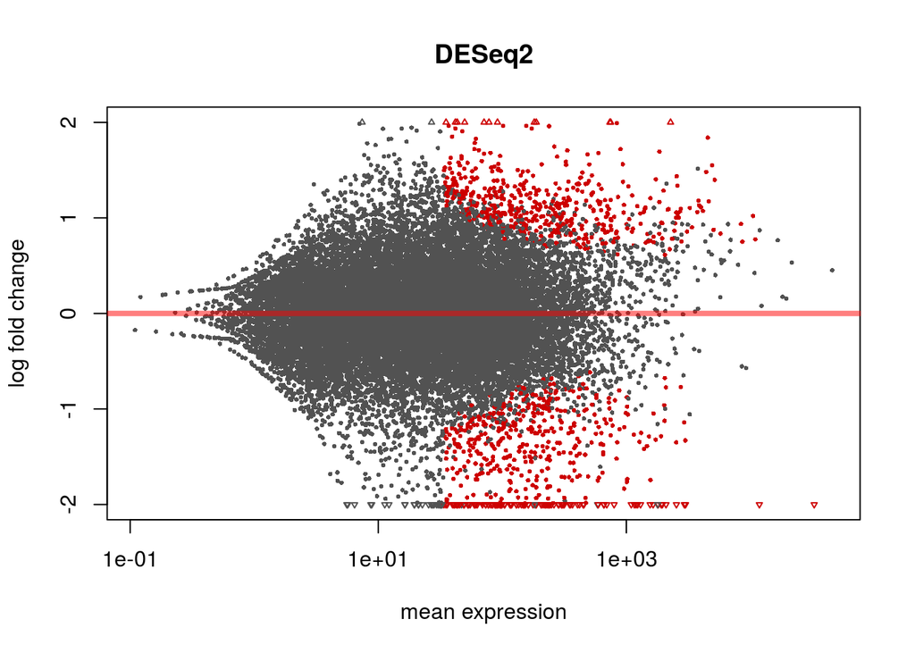

```
## integer(0)
```

```r
plotMA(res, main ="DESeq2", ylim = c(-2, 2))

identify(res$baseMean, res$log2FoldChange)
```

Esse último comando permite identificar o número da linha dos genes, clicando-se no gráfico.

Clique em um dos pontos, aperte a tecla ESC no console e depois procure no vetor $res$ a linha correspondente.

### Referências

Anders, S., & Huber, W. (2010). Differential expression analysis for sequence count data. Genome Biology, 11(10), R106.

Di, Y., Schafer, D. W., Cumbie, J. S., & Chang, J. H. (2011). The NBP negative binomial model for assessing differential gene expression from RNA-Seq. Statistical Applications in Genetics and Molecular Biology, 10, 1-28.

Love, M. I., Huber, W., & Anders, S. (2014). This Provisional PDF corresponds to the article as it appeared upon acceptance . Fully formatted Moderated estimation of fold change and dispersion for RNA-seq data with DESeq2, 1–21.

http://rstudio-pubs-static.s3.amazonaws.com/13988_bb11d85b79b2436280de434988558140.html